# HW 7

Data 180, Professor Kennedy

Justin Worobel

worobelj@dickinson.edu

December 04, 2023

**Due date:** December 4 beginning of class.

In this homework, we will analyze news headlines data scraped from abcnews, posted on Github in a csv file named `news.csv`.

Read the `news.csv` into R and create the object `news` using

```r
library(tidyverse)
library(tm)
news<-read.csv("/Users/justinworobel/Desktop/Data180-Justin-Worobel/hw7/news.csv",header=T)
```

Read also the positive and negative word dictionaries, both found on Github. This will later come in handy:

```r
posWords <- scan("/Users/justinworobel/Desktop/Data180-Justin-Worobel/hw7/positive-words.txt", character(0), sep = "\n")  # 2006 items
negWords <- scan("/Users/justinworobel/Desktop/Data180-Justin-Worobel/hw7/negative-words.txt", character(0), sep = "\n")  # 4783 items
head(posWords,15)
```

```
##  [1] "a+"            "abound"        "abounds"       "abundance"
##  [5] "abundant"      "accessable"    "accessible"    "acclaim"
##  [9] "acclaimed"     "acclamation"   "accolade"      "accolades"
## [13] "accommodative" "accomodative"  "accomplish"
```

```r
head(negWords,15)
```

```
##  [1] "2-faced"     "2-faces"     "abnormal"    "abolish"     "abominable"
##  [6] "abominably"  "abominate"   "abomination" "abort"       "aborted"
## [11] "aborts"      "abrade"      "abrasive"    "abrupt"      "abruptly"
```

# Question 1

First, check how many years of news data we have loaded in in R.

```r
years = length(unique(news$year))
cat(years, "years")
```

```
## 19 years
```

# Question 2

Store the headlines column in a vector of text named `charVector`. Print the first 6 entries in the vector.

```r
charVector = news$headline_text
print(head(charVector, 6))
```

```
## [1] "people flock to kabul airport as taliban seizes capital"
## [2] "senior liberals desert turnbull"
## [3] "interview matt scott"
## [4] "one plus one: jim cassidy"
## [5] "more australians leave lebanon"
## [6] "melb housing plan released"
```

# Question 3

Convert `charVector` into a vector source object named `wordVector` using the function `VectorSource()`. (See class notes on how to do this) Then convert `wordVector` into a corpus object named `wordCorpus` using the function `Corpus()`.

```r
wordVector = VectorSource(charVector)
wordCorpus = Corpus(wordVector)
```

# Question 4

We are now ready to do some basic trimming on the text. Do the following on the `wordCorpus` object using the `tm_map()` function, and print what’s left of the first paragraph after trimming. (Note: ignore warnings.) * Make all text lowercase * Remove punctuation * Remove numbers * Remove stopwords (e.g., the, a, at, etc.)

```r
#function for transformations
transform = function(doc) {
  doc = tolower(doc)
  doc = removePunctuation(doc)
  doc = removeNumbers(doc)
  doc = removeWords(doc, stopwords("en"))
  return(doc)
}
wordCorpus = tm_map(wordCorpus, content_transformer(transform))

print(content(wordCorpus[[1]]))
```

```
## [1] "people flock  kabul airport  taliban seizes capital"
```

# Question 5

What is a term document matrix? Explain. Create a term document matrix from the news vector and store it as an object named `tdm` using the function `TermDocumentMatrix`.

```r
# A term document matrix is a representation of a text corpus. rows represent words and columns represents documents. Each can represent the frequency of a term in a document
textCorpus = Corpus(VectorSource(charVector))
textCorpus = tm_map(textCorpus, content_transformer(transform))
tdm = TermDocumentMatrix(textCorpus)
```

# Question 6

Convert `tdm` into a matrix named `m`. Store the frequency of occurrence of each word in the news headlines in an object named `wordCounts`. Return the top 10 most frequent words. (Note: if you run into memory issues creating the matrix `m`, try using one of the computers in Tome.)

```r
m = as.matrix(tdm)
wordCounts = rowSums(m)
wordCounts_df = data.frame(word = names(wordCounts), count = wordCounts, row.names = NULL)
top_words = head(wordCounts_df[order(-wordCounts_df$count),], 10)
print(top_words)
```

```
##           word count
## 40      police   338
## 138        man   251
## 242        new   241
## 113       says   176
## 388      court   159
## 88   australia   141
## 44     council   138
## 915       fire   132
## 727 australian   126
## 153       govt   123
```

# Question 7

Create a barplot of the words that showed up at least 50 times in the news headlines. Rotate the x axis labels by 90 degrees, and decrease the label font size by 25%.

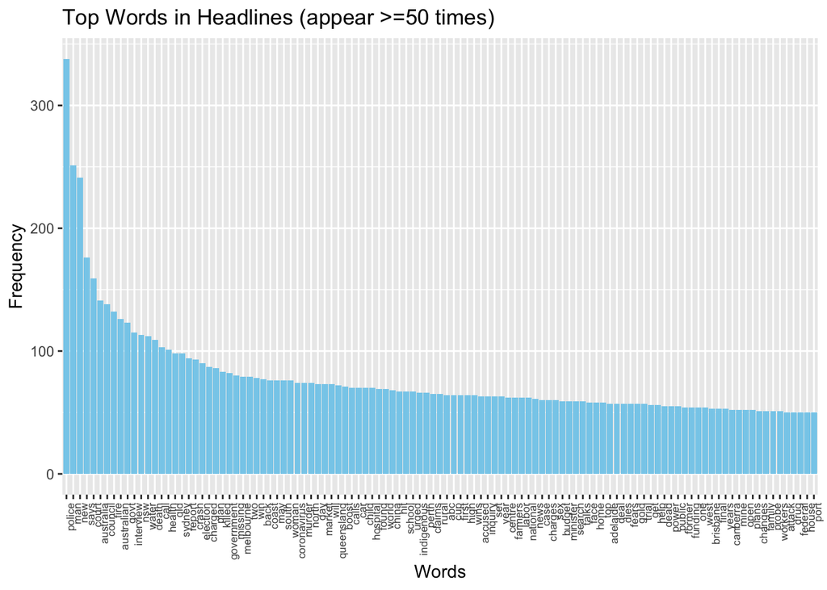

```r
library(ggplot2)
filtered_words = subset(wordCounts_df, count >= 50)
barplot_data = ggplot(filtered_words, aes(x = reorder(word, -count), y = count)) +
  geom_bar(stat = "identity", fill = "skyblue") +
  labs(title = "Top Words in Headlines (appear >=50 times)",
       x = "Words",
       y = "Frequency") +
  theme(axis.text.x = element_text(angle = 90, hjust = 1, size = rel(.75)))

print(barplot_data)
```

# Question 8

What is the percentage of positive words in the news headlines? What is the percentage of negative words? Make a barplot for each (for positive and negative words that showed up separately) showing the most frequent words for words that showed up at least 20 times. (Note: don’t forget to get the total number of unique words that showed up in the data.)

```r
library(dplyr)

freq_words_20 <- wordCounts[wordCounts >= 20]

total_unique_words <- length(wordCounts)

positive_words <- intersect(names(freq_words_20), posWords)
percentage_positive <- length(positive_words) / total_unique_words * 100

negative_words <- intersect(names(freq_words_20), negWords)
percentage_negative <- length(negative_words) / total_unique_words * 100

cat("Percentage of Positive Words:", percentage_positive, "%\n")
```

```
## Percentage of Positive Words: 0.1613684 %
```

```r
cat("Percentage of Negative Words:", percentage_negative, "%\n")
```

```
## Percentage of Negative Words: 0.3469421 %
```

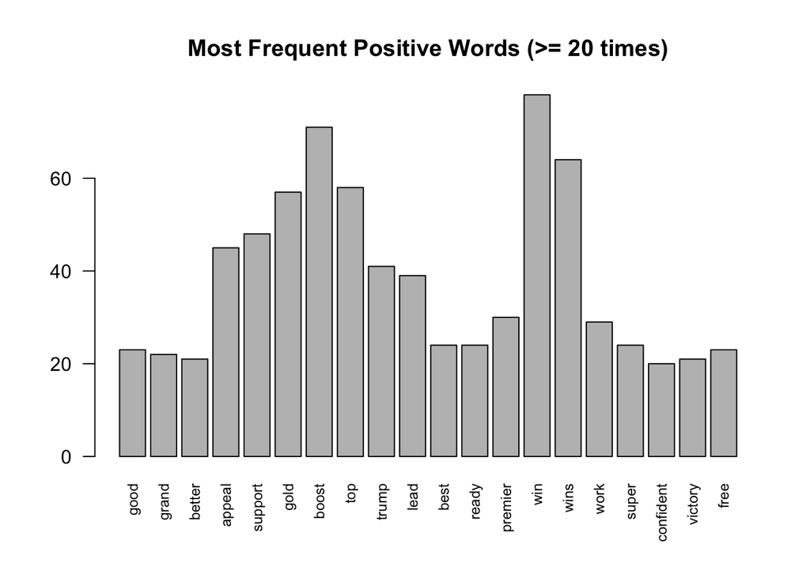

```r
barplot(freq_words_20[positive_words], las = 2, cex.names = 0.75, main = "Most Frequent Positive Words (>= 20 times)")
```

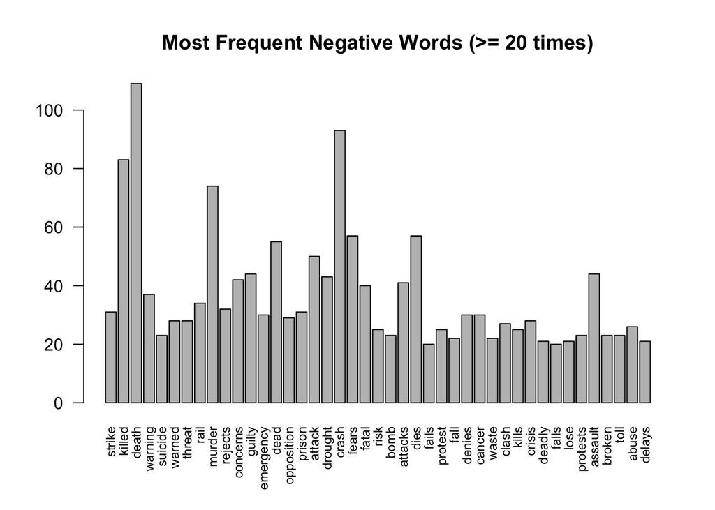

```r
barplot(freq_words_20[negative_words], las = 2, cex.names = 0.75, main = "Most Frequent Negative Words (>= 20 times)")
```

Let’s get the number of articles published in each year and month. Note that the chunk below creates two new variables `count` and `yearmonth`:

```r
news <- news %>% group_by(year,month) %>% mutate(count=n(), yearmonth = paste(year, month,sep = '/')) %>% arrange(year,month,day)
```

# Question 9

Using `ggplot2`, create a barplot for the frequency of articles released in each year and month. On the x axis, you should have year month, e.g., 2003/10, 2003/11, 2003/12, 2004/1, on the y-axis you should have the number of articles released in the data. Do you see a change in the number of articles released across years? (Hint: use `factor()` with `levels=` options specified when you call `aes(x=)` to have a proper chronological sorting on your x axis. Use `+theme(axis.text=element_text(size=4,angle=90)` to fit the dates on the x axis.)

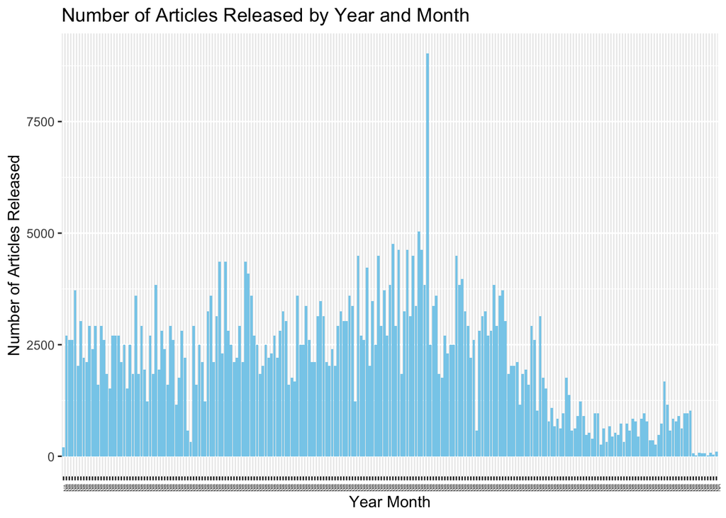

```r
ggplot(news, aes(x = factor(yearmonth, levels = unique(yearmonth)), y = count)) +
  geom_bar(stat = "identity", fill = "skyblue") +
  labs(title = "Number of Articles Released by Year and Month",
       x = "Year Month",
       y = "Number of Articles Released") +
  theme(axis.text.x = element_text(size = 4, angle = 90)) +
  scale_x_discrete(labels = function(x) format(as.Date(x, "%Y/%m"), "%Y/%m"))
```

Let’s now practice working with `quanteda` and `corpus` packages. Install the packages first if you don’t have them in your computer and load them in in R.

```r
library("quanteda")
```

# Question 10

Using the `term_stats()` function, return the 20 most frequent single words that show up in the data. Make sure to filter out * punctuation * symbols * stopwords

```r
library("quanteda")
my_corpus = corpus(charVector)

# Tokenize the corpus
my_tokens = tokens(my_corpus, remove_punct = TRUE, remove_numbers = TRUE, remove_symbols = TRUE, remove_twitter = TRUE, to_lower = TRUE)

# Create a document-feature matrix (dfm)
my_dfm = dfm(my_tokens)

# Get term frequencies
term_freqs = rowSums(my_dfm)

# Combine term frequencies with terms
term_stats = data.frame(term = names(term_freqs), frequency = term_freqs)

# Filter out stopwords, short words, etc.
filtered_term_stats = term_stats %>%
  filter(nchar(term) > 1)

# Get the top 20 words
top_words = head(filtered_term_stats[order(-filtered_term_stats$frequency),], 20)

print(top_words)
```

```
##              term frequency
## text4914 text4914        13
## text5473 text5473        13
## text393   text393        12
## text452   text452        12
## text1094 text1094        12
## text1282 text1282        12
## text1605 text1605        12
## text1966 text1966        12
## text2173 text2173        12
## text2551 text2551        12
## text2623 text2623        12
## text2786 text2786        12
## text2927 text2927        12
## text3350 text3350        12
## text3492 text3492        12
## text3561 text3561        12
## text3702 text3702        12
## text4100 text4100        12
## text4872 text4872        12
## text5679 text5679        12
```

# Question 11

Repeat the previous question for word pairs (frequency of 2 words that show up, instead of 1 word)

```r
my_corpus = corpus(charVector)

# Tokenize the corpus
my_tokens = tokens(my_corpus, remove_punct = TRUE, remove_numbers = TRUE, remove_symbols = TRUE, remove_twitter = TRUE, to_lower = TRUE)

# Create bigrams
my_bigrams_list = tokens_ngrams(my_tokens, n = 2)
my_bigrams = unlist(my_bigrams_list)

# Calculate bigram frequencies
bigram_freqs = table(my_bigrams)

# Convert to a data frame
bigram_stats = data.frame(bigram = names(bigram_freqs), frequency = as.numeric(bigram_freqs))

# Filter out stopwords, short words, etc.
filtered_bigram_stats = bigram_stats %>%
  separate(bigram, c("word1", "word2"), sep = " ") %>%
  filter(nchar(word1) > 1, nchar(word2) > 1)

# Get the top 20 bigrams
top_bigrams = head(filtered_bigram_stats[order(-filtered_bigram_stats$frequency), ], 20)

print(top_bigrams)
```

```
## [1] word1     word2     frequency
## <0 rows> (or 0-length row.names)
```

# Question 12

Create a corpus object using `corpus()` function. Store it in an object named `newscorpus`. Convert `newscorpus` into paragraphs with `corpus_reshape()`.

```r
newscorpus <- corpus(news$headline_text)

newscorpus <- corpus_reshape(newscorpus, to = "paragraphs")

head(newscorpus)
```

```
## Corpus consisting of 6 documents.
## text1 :
## "irrigators vote over river management"
##
## text2 :
## "moderate lift in wages growth"
##
## text3 :
## "us tells turkey time running out for aid offer"
##
## text4 :
## "horse ride to re enact mt isa mine find"
##
## text5 :
## "crocs prove too good for bullets"
##
## text6 :
## "oil and water does mix okay"
```

# Question 13

Create a term document matrix named `news_dtm` by using the `dfm()` function. While you call `dfm()`, make sure to clean the paragraphs by keeping only the stems of the words, removing punctuations, removing symbols, removing numbers, and removing stopwords. If you wish to get rid of anything that does not look correct in the data (such as weird bunch of characters that show up as “words”) you may trim them out at this stage using `dfm_remove()`. Finally, trim `news_dtm` such that it contains only words that show up at least 50 times. Print the first 6 rows of `news_dtm`. (Note: Again, ignore warnings.)

```r
news_tokens <- tokens(news$headline_text, remove_punct = TRUE)

news_dtm <- dfm(news_tokens, stem=TRUE, remove_punct=TRUE, remove_symbols = TRUE, remove_numbers = TRUE, remove=c(stopwords("english")))

news_dtm <- dfm_trim(news_dtm, min_termfreq = 50)

print(news_dtm[1:6, ])
```

```
## Document-feature matrix of: 6 documents, 172 features (99.42% sparse) and 0 docvars.
##        features
## docs    us time run mine find water law back warn public
##   text1  0    0   0    0    0     0   0    0    0      0
##   text2  0    0   0    0    0     0   0    0    0      0
##   text3  1    1   1    0    0     0   0    0    0      0
##   text4  0    0   0    1    1     0   0    0    0      0
##   text5  0    0   0    0    0     0   0    0    0      0
##   text6  0    0   0    0    0     1   0    0    0      0
## [ reached max_nfeat ... 162 more features ]
```

# Question 14

Create a wordcloud of `news_dtm` using `textplot_wordcloud()`. Comment on words that you were surprised and not surprised to see in the news headlines dataset.

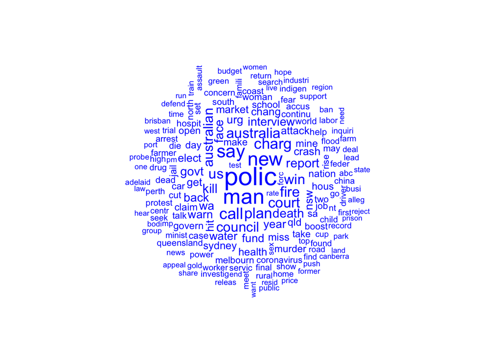

```r
library("quanteda.textplots")
wordcloud <- textplot_wordcloud(news_dtm, min_count = 50, color = "blue", scale = c(3, 0.5))
```

```r
print(wordcloud)
```

[output not shown]

[output cut: 142 more lines]

[output not shown]

Let’s now do topic modeling. Make sure to load necessary packages via

```r
library("topicmodels")
library('tidytext')
```

# Question 14

Run the LDA algorithm using k = 8. Store your output in object named `topic_model`. Print the 10 most frequent words that occurred in each 8 topic.

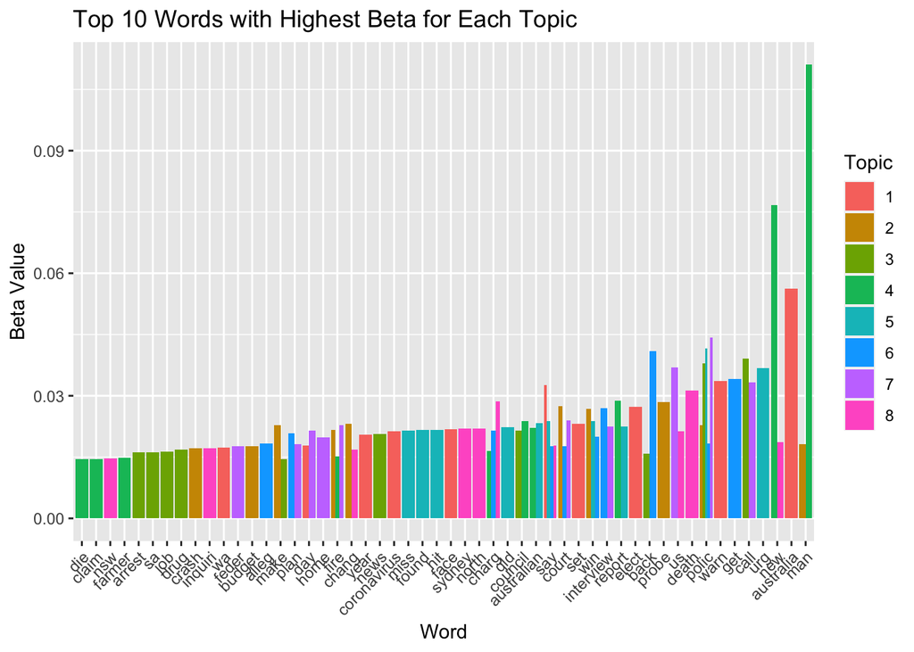

```r
library(dplyr)
news_topics <- convert(news_dtm, to = "topicmodels")
topic_model = LDA(news_topics, method = "VEM", k=8)
top_terms_beta <- tidy(topic_model, matrix = "beta") %>%
  group_by(topic) %>%
  top_n(10, beta) %>%
  ungroup() %>%
  arrange(topic, -beta)

ggplot(top_terms_beta, aes(x = reorder(term, beta), y = beta, fill = factor(topic))) +
  geom_bar(stat = "identity", position = "dodge") +
  labs(title = "Top 10 Words with Highest Beta for Each Topic",
       x = "Word",
       y = "Beta Value",
       fill = "Topic") +
  theme(axis.text.x = element_text(angle = 45, hjust = 1))
```

# Question 15

Plot betas of top 10 words with highest beta for each 8 topic. Comment on 3-4 news headline groups in terms of their topic content.

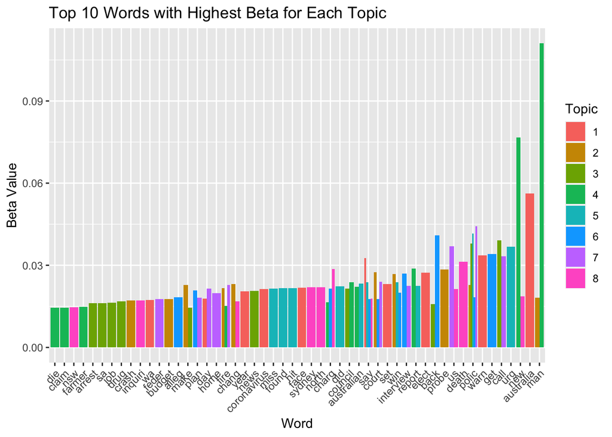

```r
top_terms_beta <- tidy(topic_model, matrix = "beta") %>%
  group_by(topic) %>%
  top_n(10, beta) %>%
  ungroup() %>%
  arrange(topic, -beta)

ggplot(top_terms_beta, aes(x = reorder(term, beta), y = beta, fill = factor(topic))) +
  geom_bar(stat = "identity", position = "dodge") +
  labs(title = "Top 10 Words with Highest Beta for Each Topic",
       x = "Word",
       y = "Beta Value",
       fill = "Topic") +
  theme(axis.text.x = element_text(angle = 45, hjust = 1))
```

# Question 16

Plot gammas of top 5 documents with highest gamma for each 8 topic. Return the contents of the 5 documents with highest gamma only for topics 1 and 2. Does it makes sense that these documents are assigned to topics 1 and 2 accordingly? Comment.

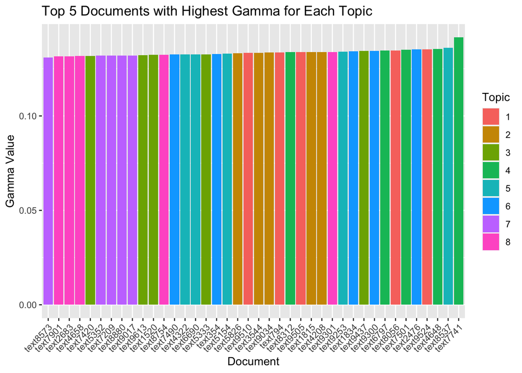

```r
top_docs_gamma <- tidy(topic_model, matrix = "gamma") %>%
  group_by(topic) %>%
  top_n(5, gamma) %>%
  ungroup() %>%
  arrange(topic, -gamma)

ggplot(top_docs_gamma, aes(x = reorder(document, gamma), y = gamma, fill = factor(topic))) +
  geom_bar(stat = "identity", position = "dodge") +
  labs(title = "Top 5 Documents with Highest Gamma for Each Topic",
       x = "Document",
       y = "Gamma Value",
       fill = "Topic") +
  theme(axis.text.x = element_text(angle = 45, hjust = 1))
```

```r
top_docs_content <- news_dtm[top_docs_gamma$document, ]

print(top_docs_content)
```

```
## Document-feature matrix of: 40 documents, 172 features (97.89% sparse) and 0 docvars.
##           features
## docs       us time run mine find water law back warn public
##   text9524  0    0   0    0    0     0   0    0    0      0
##   text8056  0    0   0    0    0     0   0    0    1      0
##   text9505  0    0   0    0    0     0   0    0    0      0
##   text794   0    0   0    0    0     0   0    0    0      0
##   text9510  0    0   0    0    0     0   0    0    0      0
##   text1815  0    0   0    0    0     0   0    0    0      0
## [ reached max_ndoc ... 34 more documents, reached max_nfeat ... 162 more features ]
```

```r
print(top_docs_content)
```

```
## Document-feature matrix of: 40 documents, 172 features (97.89% sparse) and 0 docvars.
##           features
## docs       us time run mine find water law back warn public
##   text9524  0    0   0    0    0     0   0    0    0      0
##   text8056  0    0   0    0    0     0   0    0    1      0
##   text9505  0    0   0    0    0     0   0    0    0      0
##   text794   0    0   0    0    0     0   0    0    0      0
##   text9510  0    0   0    0    0     0   0    0    0      0
##   text1815  0    0   0    0    0     0   0    0    0      0
## [ reached max_ndoc ... 34 more documents, reached max_nfeat ... 162 more features ]
```

You are done! 🏁 Don’t forget to commit and push your .Rmd file to your Github repository before the due date.